# Kokoszka_Karolina_3_projekt1.R

Karolina Kokoszka

2024-11-24

```r
# wczytanie danych
osiedla <- st_read(paste0(base_path,"AnalizaDanychPrzestrzennych/cwiczenia/lab5_projekt/osiedla.shp"))
punkty <- st_read(paste0(base_path,"AnalizaDanychPrzestrzennych/cwiczenia/lab6/zestaw3v2_XYTableToP_Project.shp"))
# wyodrębnienie współrzędnych punktów
pt_coords <- st_coordinates(punkty)
```

# Funkcja do wyznaczania osiedli/dzielnic w których wyznaczono klastry

```r
find_cluster_osiedla <- function(punkty, osiedla) {

  # przecięcie punktów klastrów z warstwą osiedli
  intersected_osiedla <- st_intersection(punkty, osiedla)

  # wyodrębnienie unikalnych nazw osiedli
  unique_osiedla <- intersected_osiedla %>%
    distinct(NAZWA_JEDN) %>%
    pull(NAZWA_JEDN)

  print("Osiedla, w których wyznaczono klastry:")
  print(unique_osiedla)
}
```

# ALGORYTM DBSCAN (Density-Based Spatial Clustering of Applications with Noise)

To algorytm klasteryzacji oparty na gęstości, który identyfikuje klastry na podstawie zagęszczenia punktów w przestrzeni.

ZASADA DZIAŁANIA:

->Obliczanie sąsiadów każdego punktu i identyfikowanie punktów rdzeniowych (punkty które w sąsiedstwie eps mają minPts punktów)

->Tworzenie klastrów przez połączenie sąsiednich punktów punktu rdzeniowego (punkty wsąsiedstwie eps - punkty bezpośrednio osiągalne z rdzenia lub punkty graniczne)

->Proces rozszerzania klastra - wykonanie dla każdego punktu nierdzeniowego:

- dodanie do sąsiedniego punktu rdzenia, jeśli to możliwe (spełnia kryterium)
- W przeciwnym razie dodanie do szumu (punkty odstające)

ZALETY:

- nie wymaga określenia liczby klastrów a priori

-może wykrywać klastry o dowolnych kształtach

- wyodrębnia szum i jest odporny na wartości odstające
- wymaga tylko dwóch parametrów i jest w większości przypadków niewrażliwy na kolejność punktów

WADY:

- wrażliwy na wybór parametrów eps i minPts (źle dobrane mogą prowadzić do błędów w klasteryzacji)
- nie klasteryzuje dobrze danych o dużych różnicach gęstości (nie da się wówczas odpowiednio dobrać kombinacji minPts-ε dla wszystkich klastrów)
- dla danych wielowymiarowych odległość euklidesowa, może być mało skuteczna (problem klątwy wymiarowości)
- nie jest całkowicie deterministyczny (w przypadku punktów granicznych, które sa osiagalne z więcej niż jednego klastra, ich przynależność zależy wówczas od kolejności przetwarzania danych)

# Funkcja do generowania mapy DBSCAN

```r
create_dbscan_map <- function(punkty,pt_coords, osiedla, eps, minPts) {
  # DBSCAN
  db <- dbscan(pt_coords, eps = eps , minPts = minPts)

  # dodanie wyników do zbioru danych (punkty)
  punkty$dbscan_cluster <- as.factor(db$cluster)  # klastry jako kolumna w danych punktowych

  # usunięcie i wyodrębnienie szumu
  punkty_bez_szumu <- punkty %>% filter(dbscan_cluster != 0)
  szum <- punkty %>% filter(dbscan_cluster == 0)

  find_cluster_osiedla(punkty_bez_szumu,osiedla)

  # generowanie mapy
  ggplot() +
    geom_sf(data = osiedla, fill = "white", color = "black") +
    geom_sf(data = punkty_bez_szumu, aes(color = dbscan_cluster), size = 1.5) +
    labs(title = paste("DBSCAN: eps =", eps, ", minPts =", minPts, ", szum-półprzeźroczysty szary"),
         color = "Cluster") +
    geom_sf(data = szum, col = "grey", size = 1.5, alpha = 0.3) +
    theme_minimal()
}
```

# DBSCAN 1

```r
eps1 <- 400 #promień otoczenia w którym sprawdzamy ilość sąsiadów
minPts1 <- 10 #minimalna ilość punktów które muszą tworzyć klaster
create_dbscan_map(punkty=punkty, pt_coords = pt_coords, osiedla = osiedla, eps = eps1, minPts = minPts1)
```

```
## [1] "Osiedla, w których wyznaczono klastry:"
##  [1] "Piaski"                          "Wzg\xf3rza Krzes\xb3awickie"
##  [3] "Krzes\xb3awice"                  "Bie\xf1czyce Stare"
##  [5] "Czy\xbfyny Lotnisko"             "Mistrzejowice"
##  [7] "Borek Fa\xb3\xeacki Wsch\xf3d"   "Borek Fa\xb3\xeacki Zach\xf3d"
##  [9] "Mateczny"                        "Wola Duchacka Zach\xf3d"
## [11] "Wola Duchacka Wsch\xf3d"         "Zab\xb3ocie"
## [13] "Czy\xbfyny Park"                 "D\xb9bie"
## [15] "Bie\xf1czyce Nowe"               "Pr\xb9dnik Czerwony"
## [17] "Pr\xb9dnik Bia\xb3y Po\xb3udnie" "Widok"
## [19] "Azory Zach\xf3d"                 "Nowa Wie\x9c Po\xb3udnie"
## [21] "Czarna Wie\x9c"                  "B\xb3onia"
## [23] "Zakrz\xf3wek"                    "Azory Wsch\xf3d"
## [25] "Krowodrza P\xf3\xb3noc"          "Krowodrza Wsch\xf3d"
## [27] "Warszawskie"                     "Olsza"
```

[output cut: 18 more lines]

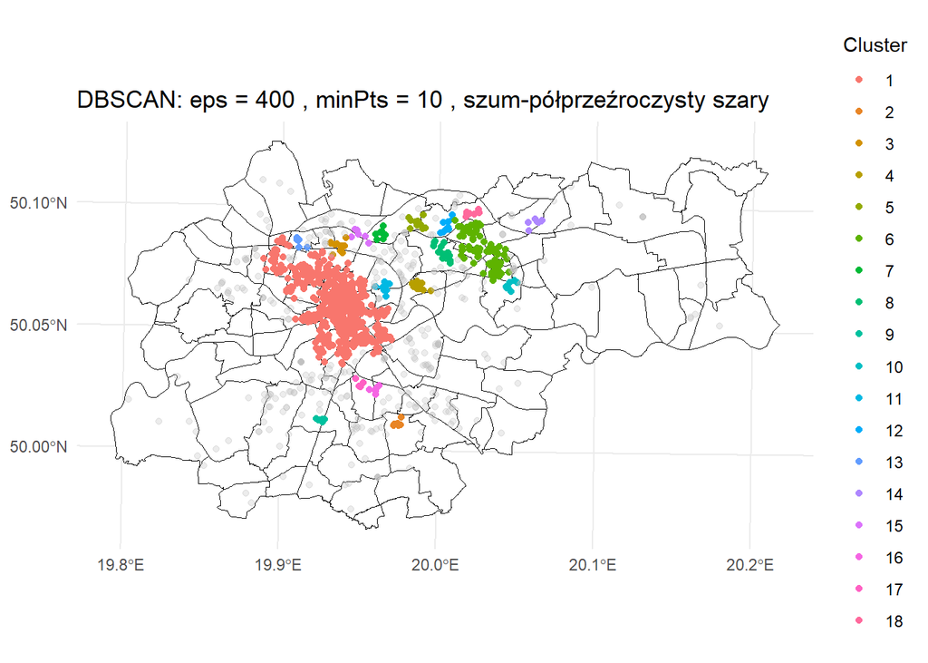

# DBSCAN 2 - zmniejszone eps

```r
eps2 <- 200
minPts2 <- 10
create_dbscan_map(punkty=punkty, pt_coords = pt_coords, osiedla = osiedla, eps = eps2, minPts = minPts2)
```

```
## [1] "Osiedla, w których wyznaczono klastry:"
##  [1] "Bie\xf1czyce Stare"            "Borek Fa\xb3\xeacki Wsch\xf3d"
##  [3] "Borek Fa\xb3\xeacki Zach\xf3d" "Zab\xb3ocie"
##  [5] "Czy\xbfyny Park"               "D\xb9bie"
##  [7] "Bie\xf1czyce Nowe"             "Nowa Wie\x9c Po\xb3udnie"
##  [9] "Czarna Wie\x9c"                "B\xb3onia"
## [11] "Zakrz\xf3wek"                  "Azory Wsch\xf3d"
## [13] "Krowodrza Wsch\xf3d"           "Warszawskie"
## [15] "Krowodrza Po\xb3udnie"         "Krowodrza - Nowa Wie\x9c"
## [17] "Osiedle Oficerskie"            "Stare Podg\xf3rze"
## [19] "Ludwin\xf3w"                   "D\xeabniki"
## [21] "P\xf3\xb3wsie Zwierzynieckie"  "Weso\xb3a Wsch\xf3d"
## [23] "Kazimierz"                     "Stradom"
## [25] "Weso\xb3a Zach\xf3d"           "Stare Miasto"
## [27] "Nowy \x8cwiat"                 "Piasek Po\xb3udnie"
## [29] "Piasek P\xf3\xb3noc"           "Kleparz"
## [31] "Zwierzyniec"                   "Bronowice Ma\xb3e Wsch\xf3d"
## [33] "Osiedle Alberty\xf1skie"       "Centrum D - Handlowe"
## [35] "Centrum C - Zgody"             "Krakowiak\xf3w - G\xf3rali"
## [37] "Centrum B - Szklane Domy"      "Centrum A - Hutnicze Ogrodowe"
## [39] "Na Skarpie"
```

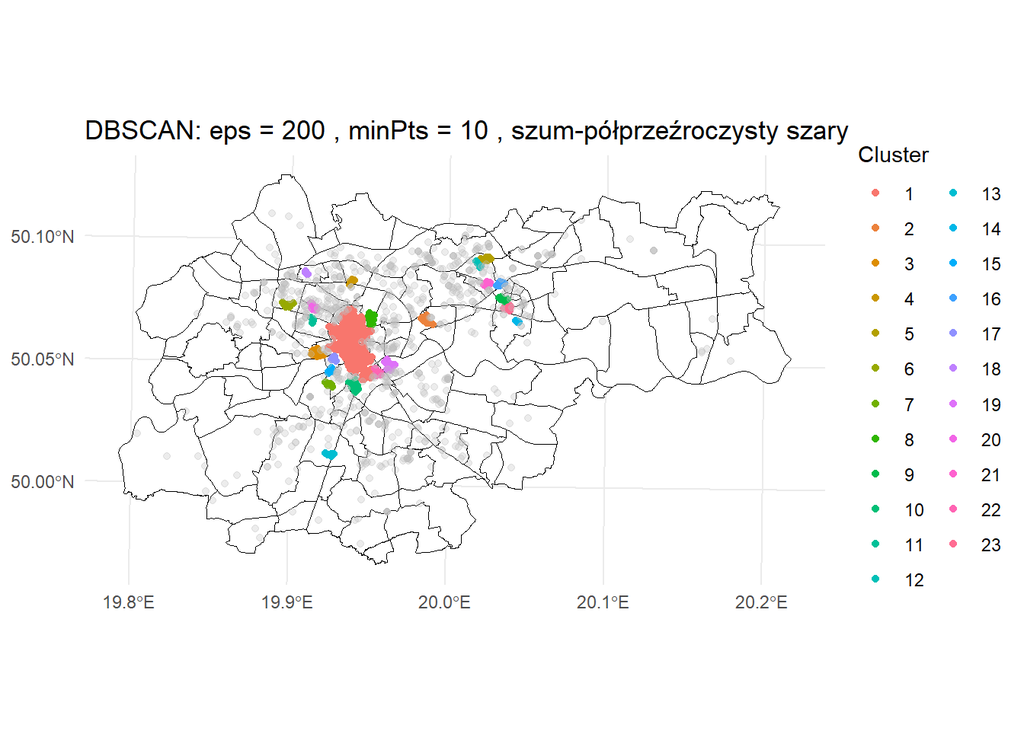

```r
#zmniejszenie eps (zbyt mała wartość) spowodowało, że:
#-duża ilość punktów jest traktowana jako szum
#-klasteryzacja tworzy za dużo małych klastrów
```

# DBSCAN 3 - zwięksozne eps

```r
eps3 <- 700
minPts3 <- 10
create_dbscan_map(punkty=punkty, pt_coords = pt_coords, osiedla = osiedla, eps = eps3, minPts = minPts3)
```

```
## [1] "Osiedla, w których wyznaczono klastry:"
##  [1] "Batowice"                        "Zarzecze"
##  [3] "R\xbf\xb9ka"                     "Piaski"
##  [5] "Kurdwan\xf3w"                    "Wzg\xf3rza Krzes\xb3awickie"
##  [7] "Krzes\xb3awice"                  "Nowy Prokocim"
##  [9] "Stary Prokocim"                  "Bie\xf1czyce Stare"
## [11] "Czy\xbfyny Lotnisko"             "Mistrzejowice"
## [13] "Czy\xbfyny \xa3\xeag"            "Skotniki"
## [15] "Pychowice"                       "Kobierzyn"
## [17] "Borek Fa\xb3\xeacki Wsch\xf3d"   "Borek Fa\xb3\xeacki Zach\xf3d"
## [19] "Mateczny"                        "Bonarka"
## [21] "Wola Duchacka Zach\xf3d"         "Wola Duchacka Wsch\xf3d"
## [23] "Kabel"                           "Zab\xb3ocie"
## [25] "P\xb3asz\xf3w"                   "Czy\xbfyny Park"
## [27] "D\xb9bie"                        "Czy\xbfyny"
```

[output cut: 29 more lines]

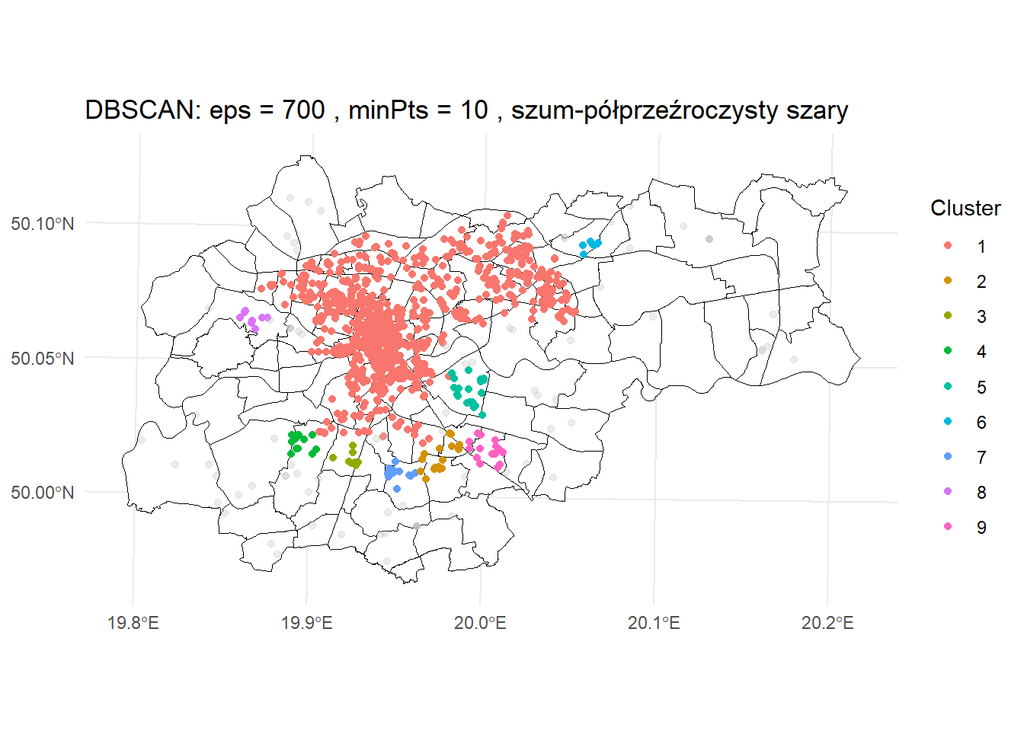

```r
# zwiększenie eps (zbyt duza wartość) spowodowało, że:
#-większość danych zostaje zgrupowana w jeden duży klaster
#-mala ilość punktów zakwalifikowanych jako szum
#-klasteryzacja przestaje być użyteczna, ponieważ większość punktow są traktowane jako jeden zbiór
```

# DBSCAN 4 - zmniejszone minPts

```r
eps4 <- 400
minPts4 <- 4
create_dbscan_map(punkty=punkty, pt_coords = pt_coords, osiedla = osiedla, eps = eps4, minPts = minPts4)
```

```
## [1] "Osiedla, w których wyznaczono klastry:"
##  [1] "Batowice"                        "\xa3uczanowice - Wad\xf3w"
##  [3] "R\xbf\xb9ka"                     "Piaski"
##  [5] "Kurdwan\xf3w"                    "Wzg\xf3rza Krzes\xb3awickie"
##  [7] "Krzes\xb3awice"                  "Nowy Prokocim"
##  [9] "Bie\xf1czyce Stare"              "Czy\xbfyny Lotnisko"
## [11] "Mistrzejowice"                   "Czy\xbfyny \xa3\xeag"
## [13] "Skotniki"                        "Pychowice"
## [15] "Kobierzyn"                       "Borek Fa\xb3\xeacki Wsch\xf3d"
## [17] "Borek Fa\xb3\xeacki Zach\xf3d"   "Mateczny"
## [19] "Bonarka"                         "Wola Duchacka Zach\xf3d"
## [21] "Wola Duchacka Wsch\xf3d"         "Kabel"
## [23] "Zab\xb3ocie"                     "P\xb3asz\xf3w"
## [25] "Czy\xbfyny Park"                 "D\xb9bie"
## [27] "Czy\xbfyny"                      "Bie\xf1czyce Nowe"
```

[output cut: 29 more lines]

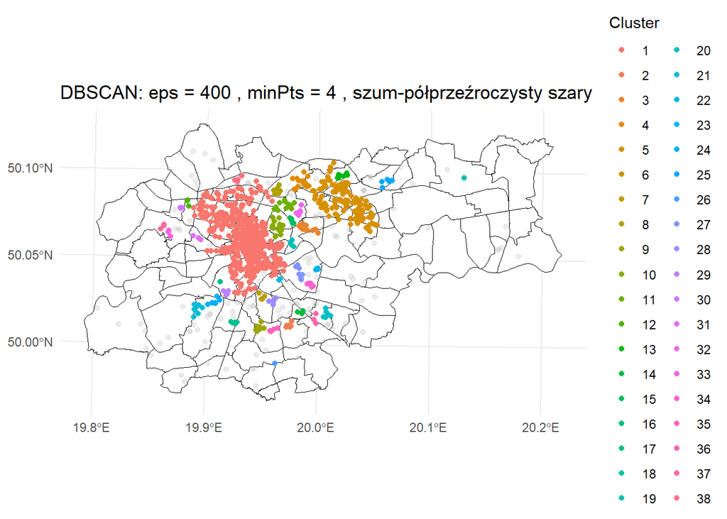

```r
# zmniejszenie minPts (zbyt mała wartość) spowodowało, że:
#-tworzy się wiele małych klastrów, z których część może być nieistotna i może być to szum
#-punktów szumu może być zbyt mało
```

# DBSCAN 5 - zwiększone minPts

```r
eps5 <- 400
minPts5 <- 16
create_dbscan_map(punkty=punkty, pt_coords = pt_coords, osiedla = osiedla, eps = eps5, minPts = minPts5)
```

```
## [1] "Osiedla, w których wyznaczono klastry:"
##  [1] "Bie\xf1czyce Stare"            "Czy\xbfyny Lotnisko"
##  [3] "Mistrzejowice"                 "Mateczny"
##  [5] "Zab\xb3ocie"                   "Czy\xbfyny Park"
##  [7] "D\xb9bie"                      "Bie\xf1czyce Nowe"
##  [9] "Pr\xb9dnik Czerwony"           "Nowa Wie\x9c Po\xb3udnie"
## [11] "Czarna Wie\x9c"                "B\xb3onia"
## [13] "Zakrz\xf3wek"                  "Krowodrza P\xf3\xb3noc"
## [15] "Krowodrza Wsch\xf3d"           "Warszawskie"
## [17] "Krowodrza Po\xb3udnie"         "Krowodrza - Nowa Wie\x9c"
## [19] "Osiedle Oficerskie"            "Grzeg\xf3rzki Wsch\xf3d"
## [21] "Kopiec Krakusa"                "Stare Podg\xf3rze"
## [23] "Ludwin\xf3w"                   "D\xeabniki"
## [25] "P\xf3\xb3wsie Zwierzynieckie"  "Weso\xb3a Wsch\xf3d"
## [27] "Grzeg\xf3rzki Zach\xf3d"       "Kazimierz"
## [29] "Stradom"                       "Weso\xb3a Zach\xf3d"
## [31] "Stare Miasto"                  "Nowy \x8cwiat"
## [33] "Piasek Po\xb3udnie"            "Piasek P\xf3\xb3noc"
## [35] "Kleparz"                       "Zwierzyniec"
## [37] "Bronowice Ma\xb3e Wsch\xf3d"   "Ma\xb3e B\xb3onia"
## [39] "Osiedle Alberty\xf1skie"       "Centrum D - Handlowe"
## [41] "Sp\xf3\xb3dzielcze - Kolorowe" "Centrum C - Zgody"
## [43] "Krakowiak\xf3w - G\xf3rali"    "Sportowe - Zielone"
## [45] "Urocze"                        "S\xb3oneczne"
## [47] "Centrum B - Szklane Domy"      "Stalowe - Willowe - Wandy"
## [49] "Centrum A - Hutnicze Ogrodowe" "Na Skarpie"
```

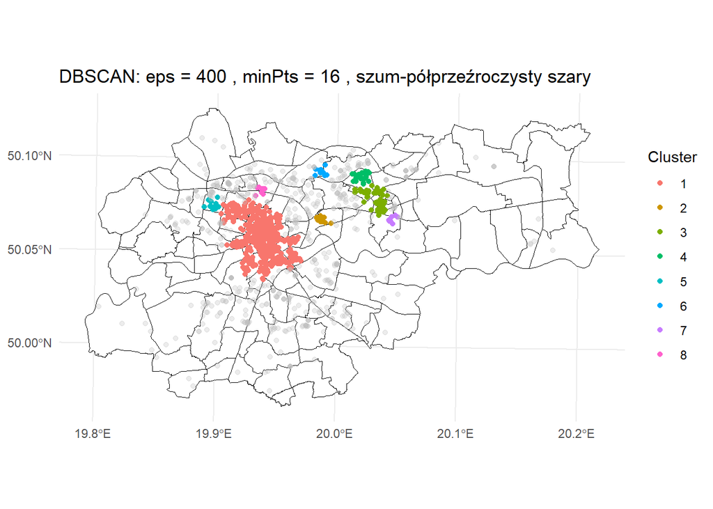

```r
# zwiekszenie minPts (zbyt duża wartość) spowodowało, że:
#-wiele punktów nie spełnia wymogu minimalnej liczby sąsiadów, przez co powstał zbyt duży szum
#-liczba klastrów jest zbyt mała
```

# ALGORYTM HDBSCAN (Hierarchical Density-Based Spatial Clustering of Applications with Noise)

To algorytm będący rozwinięciem algorytmu DBSCAN

ZASADA DZIAŁANIA:

aspekt hierarchiczny -> zamiast jednej wartości eps, HDBSCAN tworzy hierarchię klastrów, zaczynając od małych gęstych obszarów i stopniowo je łącząc w większe

->Obliczanie odległości wzajemnej osiągalności między punktami (na podstawie odległości i odległości rdzenia)

->Na podstawie obliczonej odległości wzajemnej osiągalności, konstruowane jest drzewo rozpinające sąsiedztwa między punktami

->Wykorzystanie hierarchi klastrów do identyfikacji stabilnych klastrów o zmiennej gęstości, elminacja słabo stabilnych klastrów

->Punkty należące do niestabilnych klastrów mogą byc:

- przypisane do szumu,jeśli nie spełniają minimalnych kryteriów klasteryzacji
- przypisane do innych klastrów, jeśli są osiągalne z punktów rdzeniowych w stabilnym klastrze

ZALETY:

- nie jest konieczne wartości parametru eps (dostosowywuje się do zmiennej gęstości danych)
- lepiej niż DBSCAN klasteryzuje dane o dużych różnicach gęstości
- wyodrębnia szum
- wykrywa bardziej stabilne i wiarygodne klastry dzięki hierarchicznemu podejściu (usuwając niestabilne klastry minimalizuje ryzyko nadmiernego dopasowania)

WADY:

- jest bardziej złożony obliczeniowo niż DBSCAN
- może być bardziej wrażliwy na dane szumowe niż DBSCAN, jeśli parametry są źle dobrane
- niewłaściwy dobór parametru minPts może prowadzić do błędnych wyników klasteryzacj

# Funkcja do generowania mapy HDBSCAN

```r
create_hdbscan_map <- function(punkty,pt_coords, osiedla, minPts) {
  # HDBSCAN
  hdb <- hdbscan(pt_coords, minPts = minPts)

  # dodanie wyników do zbioru danych (punkty)
  punkty$hdbscan_cluster <- as.factor(hdb$cluster) # klastry jako kolumna w danych punktowych

  # usunięcie i wyodrębnienie szumu
  punkty_bez_szumu <- punkty %>% filter(hdbscan_cluster != 0)
  szum <- punkty %>% filter(hdbscan_cluster == 0)

  find_cluster_osiedla(punkty_bez_szumu,osiedla)

  # generowanie mapy
  ggplot() +
    geom_sf(data = osiedla, fill = "white", color = "black") +
    geom_sf(data = punkty_bez_szumu, aes(color = hdbscan_cluster), size = 1.5) +
    labs(title = paste("HDBSCAN: minPts =", minPts, ", szum-półprzeźroczysty szary"),
         color = "Cluster") +
    geom_sf(data = szum, col = "grey", size = 1.5, alpha = 0.1) +
    theme_minimal()

}
```

# HDBSCAN 1

```r
minPts_h1 <- 30
create_hdbscan_map(punkty=punkty, pt_coords = pt_coords, osiedla = osiedla, minPts = minPts_h1)
```

```
## [1] "Osiedla, w których wyznaczono klastry:"
##  [1] "Krzes\xb3awice"                "Bie\xf1czyce Stare"
##  [3] "Czy\xbfyny Lotnisko"           "Mistrzejowice"
##  [5] "Czy\xbfyny Park"               "D\xb9bie"
##  [7] "Bie\xf1czyce Nowe"             "Pr\xb9dnik Czerwony"
##  [9] "Warszawskie"                   "Rakowice"
## [11] "Osiedle Oficerskie"            "Kazimierz"
## [13] "Stradom"                       "Weso\xb3a Zach\xf3d"
## [15] "Stare Miasto"                  "Nowy \x8cwiat"
## [17] "Piasek P\xf3\xb3noc"           "Kleparz"
## [19] "Osiedle Alberty\xf1skie"       "Centrum D - Handlowe"
## [21] "Sp\xf3\xb3dzielcze - Kolorowe" "Centrum C - Zgody"
## [23] "Krakowiak\xf3w - G\xf3rali"    "Sportowe - Zielone"
## [25] "Urocze"                        "S\xb3oneczne"
## [27] "Centrum B - Szklane Domy"      "Szkolne"
## [29] "Stalowe - Willowe - Wandy"     "Centrum A - Hutnicze Ogrodowe"
## [31] "Na Skarpie"
```

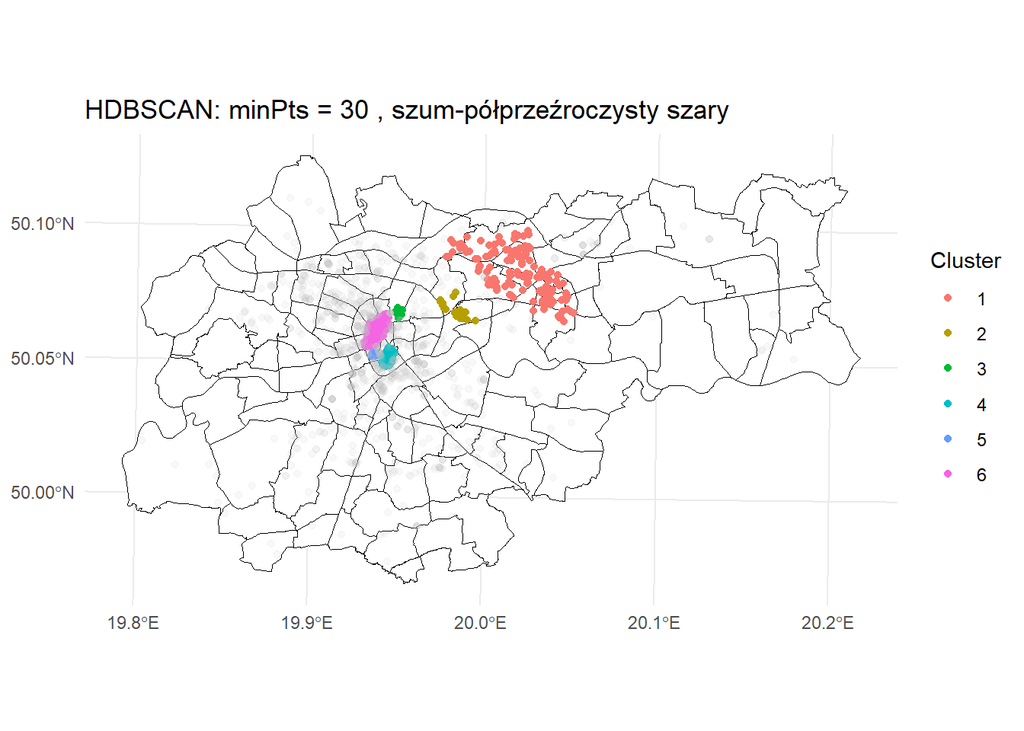

```r
# przy tak dobranej wartości minPts do klastrów zostały zakwalfikowane punkty znajdujace się w dużych skupiskach, wiele punktów zostało zakwalfikowanych jako szum
```

# HDBSCAN 2

```r
minPts_h2 <-15
create_hdbscan_map(punkty=punkty, pt_coords = pt_coords, osiedla = osiedla, minPts = minPts_h2)
```

```
## [1] "Osiedla, w których wyznaczono klastry:"
##  [1] "Piaski"                       "Kurdwan\xf3w"
##  [3] "Wzg\xf3rza Krzes\xb3awickie"  "Bie\xf1czyce Stare"
##  [5] "Czy\xbfyny Lotnisko"          "Mistrzejowice"
##  [7] "Wola Duchacka Zach\xf3d"      "Wola Duchacka Wsch\xf3d"
##  [9] "Zab\xb3ocie"                  "Czy\xbfyny Park"
## [11] "D\xb9bie"                     "Bie\xf1czyce Nowe"
## [13] "Pr\xb9dnik Czerwony"          "Nowa Wie\x9c Po\xb3udnie"
## [15] "Czarna Wie\x9c"               "B\xb3onia"
## [17] "Zakrz\xf3wek"                 "Krowodrza P\xf3\xb3noc"
## [19] "Krowodrza Wsch\xf3d"          "Warszawskie"
## [21] "Rakowice"                     "Krowodrza Po\xb3udnie"
## [23] "Krowodrza - Nowa Wie\x9c"     "Osiedle Oficerskie"
## [25] "Stare Podg\xf3rze"            "Ludwin\xf3w"
## [27] "D\xeabniki"                   "P\xf3\xb3wsie Zwierzynieckie"
## [29] "Kazimierz"                    "Stradom"
## [31] "Stare Miasto"                 "Nowy \x8cwiat"
## [33] "Kleparz"                      "Zwierzyniec"
## [35] "Bronowice Ma\xb3e Wsch\xf3d"  "Osiedle Alberty\xf1skie"
## [37] "Centrum D - Handlowe"         "Centrum C - Zgody"
## [39] "Krakowiak\xf3w - G\xf3rali"   "Urocze"
## [41] "Centrum B - Szklane Domy"     "Stalowe - Willowe - Wandy"
## [43] "Koz\xb3\xf3wek"               "Na Skarpie"
```

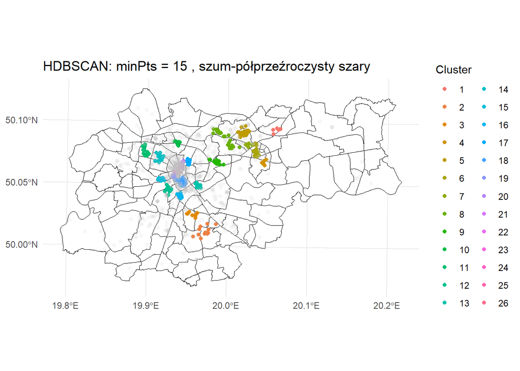

```r
# przy tak dobranej wartości minPts zwiększyła się liczba klastrówi (niektóre klastry zostały utworzone z punktów znajdujących się poza głównymi skupiskami) i lekko zmniejszył się szum
```

# HDBSCAN 3

```r
minPts_h3 <- 6
create_hdbscan_map(punkty=punkty, pt_coords = pt_coords, osiedla = osiedla, minPts = minPts_h3)
```

```
## [1] "Osiedla, w których wyznaczono klastry:"
##  [1] "Bronowice Wielkie"               "Batowice"
##  [3] "Zarzecze"                        "Nowy Bie\xbfan\xf3w"
##  [5] "R\xbf\xb9ka"                     "Piaski"
##  [7] "Kurdwan\xf3w"                    "Wzg\xf3rza Krzes\xb3awickie"
##  [9] "Krzes\xb3awice"                  "Nowy Prokocim"
## [11] "Stary Prokocim"                  "Bie\xf1czyce Stare"
## [13] "Czy\xbfyny Lotnisko"             "Mistrzejowice"
## [15] "Czy\xbfyny \xa3\xeag"            "Skotniki"
## [17] "Pychowice"                       "Kobierzyn"
## [19] "Borek Fa\xb3\xeacki Wsch\xf3d"   "Borek Fa\xb3\xeacki Zach\xf3d"
## [21] "Mateczny"                        "Bonarka"
## [23] "Wola Duchacka Zach\xf3d"         "Wola Duchacka Wsch\xf3d"
## [25] "Kabel"                           "Zab\xb3ocie"
## [27] "P\xb3asz\xf3w"                   "Czy\xbfyny Park"
```

[output cut: 31 more lines]

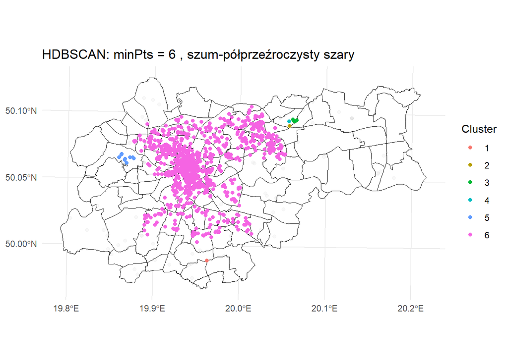

```r
# źle dobana wartosć minPts spowodowała, że większość danych zostaje zgrupowana w jeden duży klaster oraz mala ilość punktów należy do szum
```

# WNIOSKI

Jeśli skupiamy się na analizie obszarów o różnej gęstości (np. centrum miasta i obrzeża), HDBSCAN wydaje się być bardziej odpowiednim algorytmem dzięki zdolności adaptacji do lokalnej gęstości(natomiast HDBSCAN jest trudniejszy w diagnozowaniu problemów z parametrami). W przypadku DBSCAN należy eksperymentalnie dostroić eps i minPts w taki sposób, aby uwzględniały różnice w rozkładzie punktów między centrum a obrzeżami.

Na podstawie otrzymanych wyników, można stwierdzić, że najwięcej zarejestrowanych wykroczń występuje w rejonie Starego Miasta i jego okolicach (dzielnice Krowodrza i Grzegórzki), a następnie okolice Mistrzejowic i Bieńczyc.